# Lab11

Davyd Antoniuk

2024-05-20

```r
library(MASS)
library(dplyr)
library(tidyverse)
library(ggplot2)
library(knitr)
library(moments)
library(psych)
library(nortest)
```

## Zadanie 1

Fabryka samochodów do pomalowania karoserii używa czterech kolorów: żółty, czerwony, czarny i biały. Chcemy stwierdzić, czy kolory te są jednakowo popularne wśród kupujących. W tym celu zapytano potencjalnych klientów jaki kolor karoserii wybraliby kupując samochód i uzyskano następujące odpowiedzi 91 zakupiłoby samochód w kolorze czarnym, 26 – żółtym, 41 – czerwonym i 42 – białym. Na podstawie otrzymanej próby zweryfikuj hipotezę o tym, że (A) wszystkie cztery kolory są jednakowo popularne. (B) kolory czerwony, żółty i biały są tak samo popularne, a kolor czarny jest „dwa razy bardziej popularny”.

```r
dane <- data.frame(kolor = c('czarny (1)', 'żółty (2)', 'czrewony (3)', 'biały (4)'), zaobserwowane = c(91, 26, 41, 42))
```

```r
zaobserwowane <-  c(91, 26, 41, 42)
```

### (A)

Musimy zbadać czy karoseria ma rozkład jednostajny dyskretny z prawdopodobieństwem $\frac{1}{4}$.

$H_0:$ Rozkład popularności kolorów jest rozkładem równomiernym z parametrem 1/4.

Rodzaj hipotezy: nieparametryczna, prosta, bo mamy parametry jednoznaczowe.

$H_1:$Rozkład popularności kolorów jest inny niż równomierny z parametrem 1/4.

```r
oczekiwane1 <- c(50,50,50,50)
chisq.test(dane$zaobserwowane,p=oczekiwane1/sum(zaobserwowane))
```

```
##
##  Chi-squared test for given probabilities
##
## data:  dane$zaobserwowane
## X-squared = 48.04, df = 3, p-value = 2.088e-10
```

```r
#chisq.test(dane2$zaobserwowane,p=c(1/4,1/4,1/4,1/4)) #drugi argument - prawdopod . teoretyczne(musi w sumie dawać 0)
```

Przeprowadzilem test zgodności chi-kwadrat zaproponowany przez Karla Pearsona. Otrzymłem p-wartość równa 2.088e-10. Jest ona mniejsza od pięciu setnych(0.05), więc rzucamy $H_0$, na korzyść hipotezy alternatywnej. Na podstawie otrzymanego testu możemy twierdzić że te cztery kolory nie są jednakowo popularne.

### (B)

Zdefiniujemy rozklad dyskretny za pomocą, funkcji prawdopodobieństwa

$P[X=czarny]=2/5$ $P[X=żółty]=1/5 \ P[X=czerwony]=1/5 \ P[X=biały]=1/5$ $H_0:$ Rozkład kolorów karoserii jest zdefiniowany poniższą funkcją prawdopodobieństwa

$H_1:$ Rozkład kolorów karoserii jest rozkładem dany funkcją prawdopodobieństwa inną niż powyższa

```r
oczekiwane2 <- c(80,40,40,40)
chisq.test(dane$zaobserwowane,p= oczekiwane2/sum(zaobserwowane))
```

```
##
##  Chi-squared test for given probabilities
##
## data:  dane$zaobserwowane
## X-squared = 6.5375, df = 3, p-value = 0.0882
```

Przeprowadzilem test zgodności chi-kwadrat zaproponowany przez Karla Pearsona. Otrzymłem p-wartość równa 0.0882.Otrzymana p-wartość jest większa niż pięć setnych(0.05) więc nie mamy podstaw do odrzucenia hipotezy zerowej. Na podstawie otrzymanego testu możemy twierdzić że kolor czarny ma szanse być dwa razy bardziej popularny niż inne kolory.

Niech $\mu_p$ - średnia waga noworodka matki palącej $\mu_n$ - średnia waga noworodka matki niepalącej

$H0:$ $\mu_p$ =$\mu_n$ $H1:$ $\mu_p$<$\mu_n$ Rozkłady wagi noworodków jest rozkładem normalnym

```r
dane2 <- MASS::birthwt
head(dane2)
```

```
##    low age lwt race smoke ptl ht ui ftv  bwt
## 85   0  19 182    2     0   0  0  1   0 2523
## 86   0  33 155    3     0   0  0  0   3 2551
## 87   0  20 105    1     1   0  0  0   1 2557
## 88   0  21 108    1     1   0  0  1   2 2594
## 89   0  18 107    1     1   0  0  1   0 2600
## 91   0  21 124    3     0   0  0  0   0 2622
```

###(A)

```r
daneA <- data.frame(palenie=dane2$smoke,waga=dane2$bwt)
head(daneA)
```

```
##   palenie waga
## 1       0 2523
## 2       0 2551
## 3       1 2557
## 4       1 2594
## 5       1 2600
## 6       0 2622
```

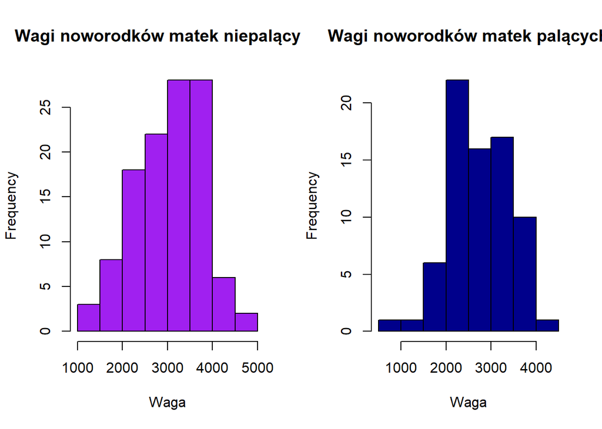

```r
niepalace <- daneA %>% filter(palenie==0)
palace <- daneA %>% filter(palenie==1)

par(mfrow=c(1,2))

hist(niepalace$waga, main="Wagi noworodków matek niepalących", xlab="Waga", col="purple", border="black")

hist(palace$waga, main="Wagi noworodków matek palących", xlab="Waga", col="darkblue", border="black")
```

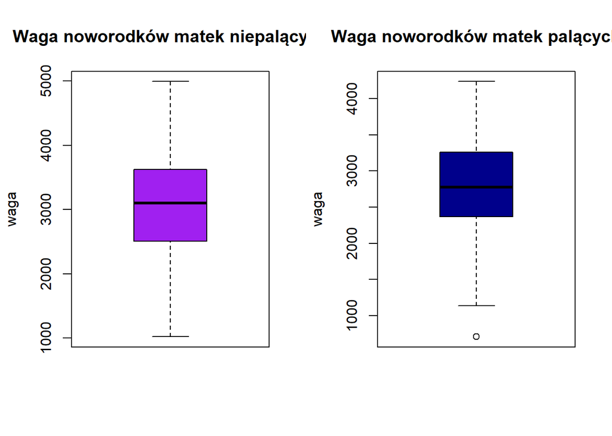

```r
par(mfrow=c(1,1))

par(mfrow=c(1,2))

boxplot(niepalace$waga, main="Waga noworodków matek niepalących", ylab="waga", col="purple" )

boxplot(palace$waga, main="Waga noworodków matek palących", ylab="waga", col="darkblue" )
```

```r
par(mfrow = c(1, 1))
```

### (B)

```r
skosnosc <- round(c(skewness(niepalace$waga), skewness(palace$waga)),2)
kurtoza <- round(c(kurtosis(niepalace$waga), kurtosis(palace$waga)),2)
miary <- rbind.data.frame(skosnosc,kurtoza)
colnames(miary) <- c("Niepalące", "Palące")
rownames(miary) <- c("Skośność","Kurtoza")

print(miary)
```

```
##          Niepalące Palące
## Skośność     -0.29  -0.28
## Kurtoza       2.73   3.32
```

Dla matek niepalących rozkład wagi noworodka jest lewostronnie asymetryczny i platykurtyczny

Dla matek palących rozkład wagi noworodka jest lewostronnie asymetryczny i mezokurtyczny

### (C)

Na podstawie otrzymanej skośności i kurtozy można przypuszczać, że rozkłady wagi noworodków w obu przypadkach są normalne.

### (D)

$H_0:$ Rozkład wagi noworodka matki niepalącej jest rozkładem normalnym $H_1:$ Rozkład wagi noworodka matki niepalącej jest rozkładem innym niż rozkład normalny.

```r
ad.test(niepalace$waga) #Andersona-Darlinga
```

```
##
##  Anderson-Darling normality test
##
## data:  niepalace$waga
## A = 0.50215, p-value = 0.2023
```

```r
shapiro.test(niepalace$waga) #Shapiro-Wilka
```

```
##
##  Shapiro-Wilk normality test
##
## data:  niepalace$waga
## W = 0.98694, p-value = 0.3337
```

```r
fBasics::dagoTest(niepalace$waga)# test D’Agostino
```

```
##
## Title:
##  D'Agostino Normality Test
##
## Test Results:
##   STATISTIC:
##     Chi2 | Omnibus: 1.8998
##     Z3  | Skewness: -1.3139
##     Z4  | Kurtosis: -0.4166
##   P VALUE:
##     Omnibus  Test: 0.3868
##     Skewness Test: 0.1889
##     Kurtosis Test: 0.677
```

Na podtawie przeprowadzonych testów: Andersona-Darlinga; Shapiro-Wilka; D’Agostino W grupie matek niepalących Wartości p w przeprowadzonych testach są większe od 0.05, zatem nie mamy podstaw do odrzucenia hipotezy zerowej. Na podstawie otrzymanych testów możemy twierdzić że rozkład wagi noworodka matki niepalącej jest rozkładem normalnym

$H_0:$ Rozkład wagi noworodka matki palącej jest rozkładem normalnym

$H_1:$ Rozkład wagi noworodka matki palącej jest rozkładem innym niż rozkład normalny.

```r
ad.test(palace$waga) #Andersona-Darlinga
```

```
##
##  Anderson-Darling normality test
##
## data:  palace$waga
## A = 0.30252, p-value = 0.5668
```

```r
shapiro.test(palace$waga) #Shapiro-Wilka
```

```
##
##  Shapiro-Wilk normality test
##
## data:  palace$waga
## W = 0.98296, p-value = 0.4195
```

```r
fBasics::dagoTest(palace$waga)# test D’Agostino
```

```
##
## Title:
##  D'Agostino Normality Test
##
## Test Results:
##   STATISTIC:
##     Chi2 | Omnibus: 1.9716
##     Z3  | Skewness: -1.0673
##     Z4  | Kurtosis: 0.9124
##   P VALUE:
##     Omnibus  Test: 0.3731
##     Skewness Test: 0.2858
##     Kurtosis Test: 0.3615
```

Na podtawie przeprowadzonych testów: Andersona-Darlinga; Shapiro-Wilka; D’Agostino W grupie matek palących Wartości p są większe od 0.05, zatem nie mamy podstaw do odrzucenia hipotezy zerowej. Na podstawie otrzymanych testów możemy twierdzić że rozkład wagi noworodka matki palącej jest rozkładem normalnym

Na podstawie przeprowadzonych testów można przypuszcza, że rozważane dane w obu grupach pochodzą z rozkładu normalnego.

### (E)

W tym przypadku przeprowadzamy test na równość średnich dwóch populacji Jest to przypadek drugi (dwie niezależn próby o różnej liczebności), dlatego najpierw należy zrobić test na równość wariancji dwóch populacji

$\mu_p$ - średnia waga noworodka matki palącej $\mu_n$ - średnia waga noworodka matki niepalącej

-TEST NA RÓWNOŚĆ WARIANCJI

$H_0:$ Wariancje rozkładów wagi noworodków w obu grupach są takie same $H_0:\sigma_1^2=\sigma_2^2$

$H_1:$ Wariancje rozkładów wagi noworodków są różne w obu grupach.
$$H_1:\sigma_1^2\neq\sigma_2^2$$

```r
a = 0.01
```

```r
n1 <- length(palace$waga)
n2 <- length(niepalace$waga)
n1
```

```
## [1] 74
```

```r
n2
```

```
## [1] 115
```

```r
S1 <- ((n1-1)/n1)*var(palace$waga)
S2 <- ((n2-1)/n2)*var(niepalace$waga)     #uwaga! to ma być obciążony estymator dlatego domnażamy przez (n-1)/n. Samo var() oblicza nieobciążony estymtor wariancji.
# uwaga 2 są to s1^2 i s2^2 dlatego w późniejszych wzorach nie podnosimy do kwadratu

Fs <- S1/S2
Fs
```

```
## [1] 0.7643593
```

```r
qf(0.01/2, n1-1, n2-2)
```

```
## [1] 0.5676319
```

```r
qf((1-0.01/2), n1-1, n2-2)
```

```
## [1] 1.712512
```

Obszar krytyczny to:
$$[0;0.5676319]\cup[1.712512;\infty]$$

```r
#var.test(dane$bwt[dane$smoke == 0], dane$bwt[dane$smoke == 1]) #test variancji
#var.test(palace$waga,niepalace$waga) #test variancji
```

Wartość statystyki testowej F nie zawiera się w obszarze krytycznym, zatem nie ma podstaw do odrzucenia hipotezy zerowej (zakładającej równość wariancji)Więc na podstawie tego możemy twierdzić że wariancje rozkladów w obu grupach są równe.

-TEST NA RÓWNOŚĆ ŚREDNICH

$H0:$ $\mu_p$ =$\mu_n$ $H1:$ $\mu_p$<$\mu_n$

$\mu_p$ - średnia waga noworodka matki palącej $\mu_n$ - średnia waga noworodka matki niepalącej

```r
p_s <- mean(palace$waga)
n_s <- mean(niepalace$waga)
p_s
```

```
## [1] 2771.919
```

```r
n_s
```

```
## [1] 3055.696
```

```r
Sp2 <- (((S1)*(n1-1))+((S2)*(n2-1)))/(n1+n2-2)
Sp <- sqrt(Sp2)
Sp
```

```
## [1] 714.0788
```

```r
Ts <- (p_s-n_s)/(Sp*(sqrt(1/n1+ 1/n2)))
Ts
```

```
## [1] -2.666641
```

```r
qnorm(1-0.01, n1+n2-2)
```

```
## [1] 189.3263
```

Obszar krytyczny:
$$(-\infty;189.3263)$$

Wartość statystyki testowej zawiera się w obszarze krytycznym, dlatego odrzucamy hipotezę zerową.

Na podstawie danych oraz przeprowadzonych testów możmy twierdzić, że średnia waga noworodków matek palących jest mniejsza od średniej wagi noworodków matek niepalących.

```r
# t.test(dane$bwt[dane$smoke == 0], dane$bwt[dane$smoke == 1], var.equal = TRUE)
```